# Homework 2, Eastoa01

Rename the blood_type_factor in the above example as follows:  
levels(blood_type_factor) <- c(“BT_A”, “BT_B”, “BT_AB”, “BT_O”)  
and justify the result of outputting blood_type_factor. Use str() to support your answer.

```r
blood_type <- c("B", "A", "AB", "A", "O")
blood_type_factor <- factor(blood_type)
levels(blood_type_factor) <- c("BT_A", "BT_B", "BT_AB", "BT_O")
print(blood_type_factor)
```

```
## [1] BT_AB BT_A  BT_B  BT_A  BT_O
## Levels: BT_A BT_B BT_AB BT_O
```

```r
str(blood_type_factor)
```

```
##  Factor w/ 4 levels "BT_A","BT_B",..: 3 1 2 1 4
```

The issue seems to be order. When we make blood_type into a factor, it reorders things, but not in the order that I re-labeled the levels.

Use the inequality operator (< or >) on a nominal category and print the output.

```r
1 > 2
```

```
## [1] FALSE
```

```r
blood_test <- list(Fluid="Blood sugar", Category="High", Value=140, Units="mg/dL")
patient <- list(Name="Mike", Age=36, Btest = blood_test)
```

What does patient[c(1,3)] give us? *A list.*

```r
patient[c(1,3)]
```

```
## $Name
## [1] "Mike"
##
## $Btest
## $Btest$Fluid
## [1] "Blood sugar"
##
## $Btest$Category
## [1] "High"
##
## $Btest$Value
## [1] 140
##
## $Btest$Units
## [1] "mg/dL"
```

```r
class(patient[c(1,3)])
```

```
## [1] "list"
```

What does patient[[c(1,3)]] give us? *An error, because there’s no 3rd item in the first item on the list.*

```r
#patient[[c(1,3)]]
#Error in patient[[c(1, 3)]] : subscript out of bounds
```

How about patient[[c(3,1)]]? *A character. It gave us the first value in the 3rd item.*

```r
patient[[c(3,1)]]
```

```
## [1] "Blood sugar"
```

```r
class(patient[[c(3,1)]])
```

```
## [1] "character"
```

How do you remove an element from a list? *I just removed the whole column, which probably isn’t right. So for good measure, I also made the age into NA.*

```r
patient$Name <- NULL
patient[c(1)] <- NA
patient
```

```
## $Age
## [1] NA
##
## $Btest
## $Btest$Fluid
## [1] "Blood sugar"
##
## $Btest$Category
## [1] "High"
##
## $Btest$Value
## [1] 140
##
## $Btest$Units
## [1] "mg/dL"
```

### Data frames

My data frame is 4 observations of 3 variables. Name is a factor with 4 levels, Age is a numeric variable, and Cancer_Status is logical.  
If you try to combine vectors with unequal length into a data frame, you get the following error message:

Error in data.frame(Name = name, Age = age, Cancer_Status = cancer) : arguments imply differing number of rows: 4, 3

Test the operations of lists (like [“age”] & [[“age”]]) on data frames.

```r
class(df["Age"]) # Prints a data frame with just one column
```

```
## [1] "data.frame"
```

```r
class(df[["Age"]]) #Prints a numeric vector
```

```
## [1] "numeric"
```

```r
df2 <- cbind(df,Family_History=c(TRUE,TRUE,FALSE,FALSE,FALSE))
```

What happens if the length of the appending vector is greater than (or less than) row dimensions? *If the appending vector has too many or too few elements, you get an error message about the number of rows.*

Can you use the list() function instead of the data frame function in the above code? *YES* What happens if you leave the arguments name=, age= etc. in the above code?

```r
tom <- list(Name="Mary", Age=37, Cancer_Status="FALSE", Tumor_size="T0")
df <- rbind(df, tom)
```

What happens if you leave *out* the arguments name=, age= etc. in the above code? *It doesn’t work; you get an error saying the names don’t match.*

Check out the function expand.grid(), what is it for? *expand.grid creates a data frame from all combinations of factor variables.* Try out the following example and think when it is useful.

```r
expand.grid(height = as.character(seq(60, 70, 5)), weight = seq(100, 200, 50),
            sex = c("Male","Female"), stringsAsFactors = FALSE)
```

```
##    height weight    sex
## 1      60    100   Male
## 2      65    100   Male
## 3      70    100   Male
## 4      60    150   Male
## 5      65    150   Male
## 6      70    150   Male
## 7      60    200   Male
## 8      65    200   Male
## 9      70    200   Male
## 10     60    100 Female
## 11     65    100 Female
## 12     70    100 Female
## 13     60    150 Female
## 14     65    150 Female
## 15     70    150 Female
## 16     60    200 Female
## 17     65    200 Female
## 18     70    200 Female
```

*This creates a data frame that contains every possible combination of height, weight and sex. Thus there are (3 heights)x(3 weights)x(2 sexes)=18 total rows. This might be useful if you wanted to study the ways these variables affected an outcome such as having diabetes, and wanted to look at people with all different combinations of these variables so that you could tease out the effect of each one.*

Why does sort(df$age) return an error? *It doesn’t return an error for me, it just creates a (somewhat useless) ordered numeric vector of ages.* When you fix the problem, what does the command perform and how is it related to the ranks? *I didn’t get an error so I don’t know* Sort the entries in descending order of the age. (Hint: Question the function to find out more about the function in question). *I used order and then sorted according to those ranks, as in the example. Sort sorts a vector or factor in order, but order is used for sorting data frames by one variable. Order rearranges its first argument into ascending or descending order. This can then be applied to the data frame.*

```r
sorted <- sort(df$Age)
ordered <- order(df$Age)
df_ordered <- df[ordered,]
```

## Graphics

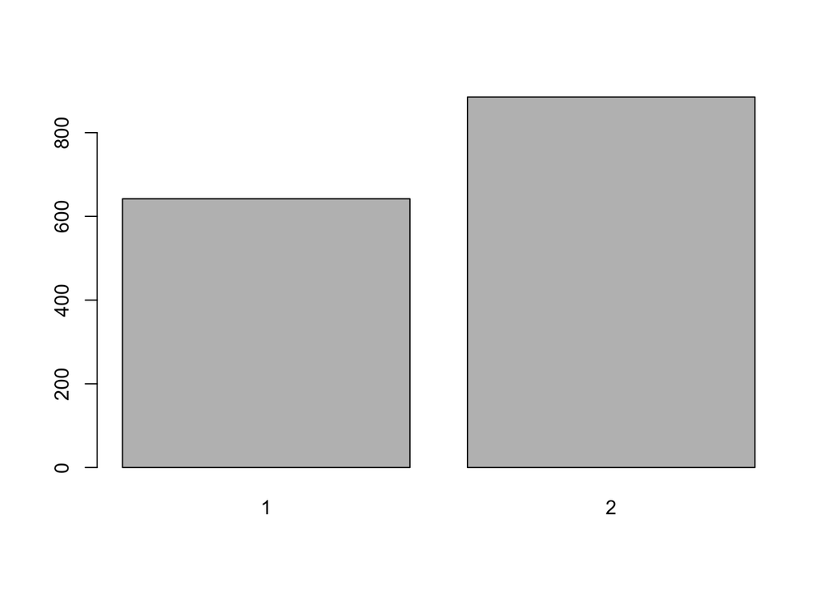

*This plot is not very informative, because we don’t know which factor (1 or 2) is males. Relabelling would make it more helpful.*

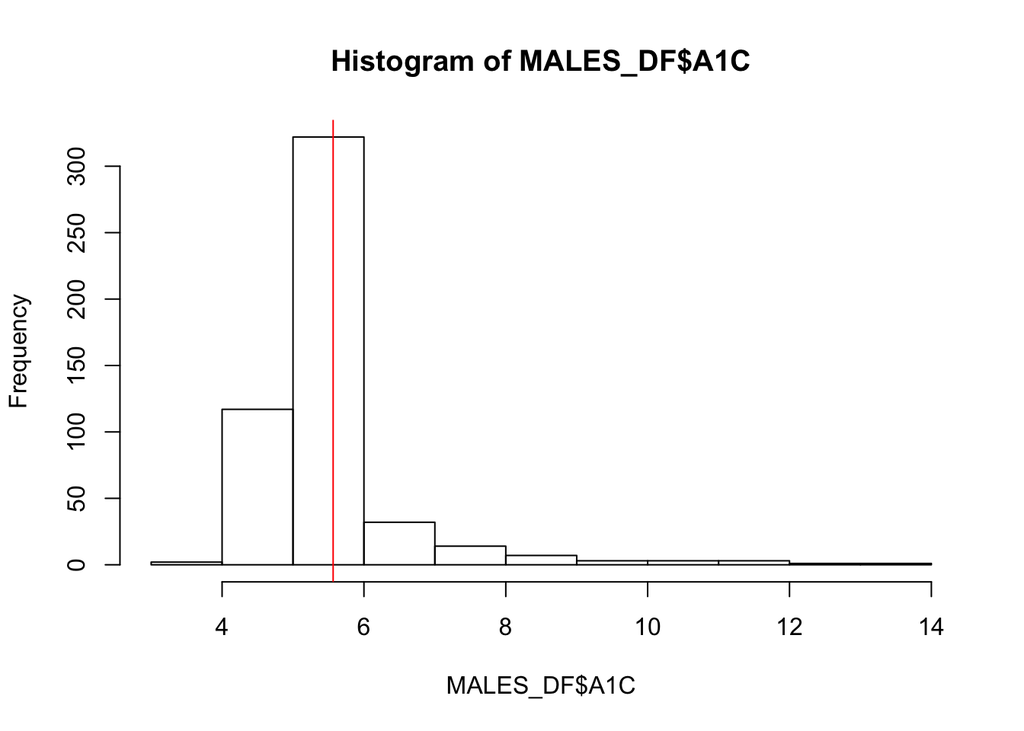

Find the distribution of A1C for the female population in the above data set. Are they different?

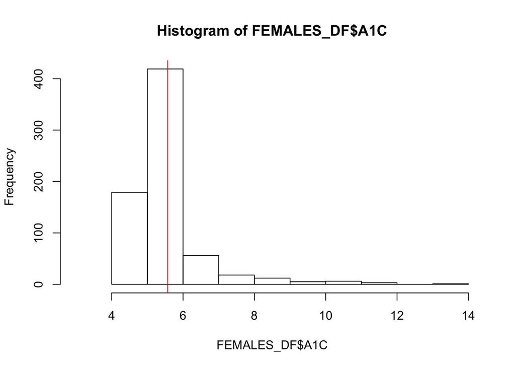

```r
HANES_FEMALE <- HANES$GENDER == "F"
FEMALES_DF <- HANES[HANES_FEMALE,]
hist(FEMALES_DF$A1C,xlim=c(3,14))
abline(v = mean(FEMALES_DF$A1C, na.rm = T), col="red")
```

*They look quite similar. I adjusted the x axis to make them more easily visually comparable.*

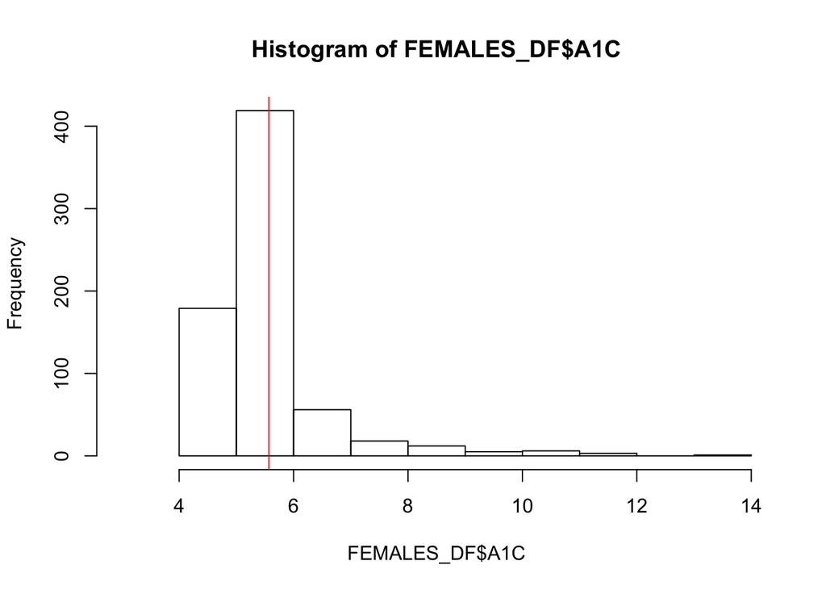

```r
hist(FEMALES_DF$A1C,xlim=c(3,14))
abline(v = mean(FEMALES_DF$A1C, na.rm = T), col="red")
```

Find the distribution of A1C for three age groups in the above data set. Is there a difference?

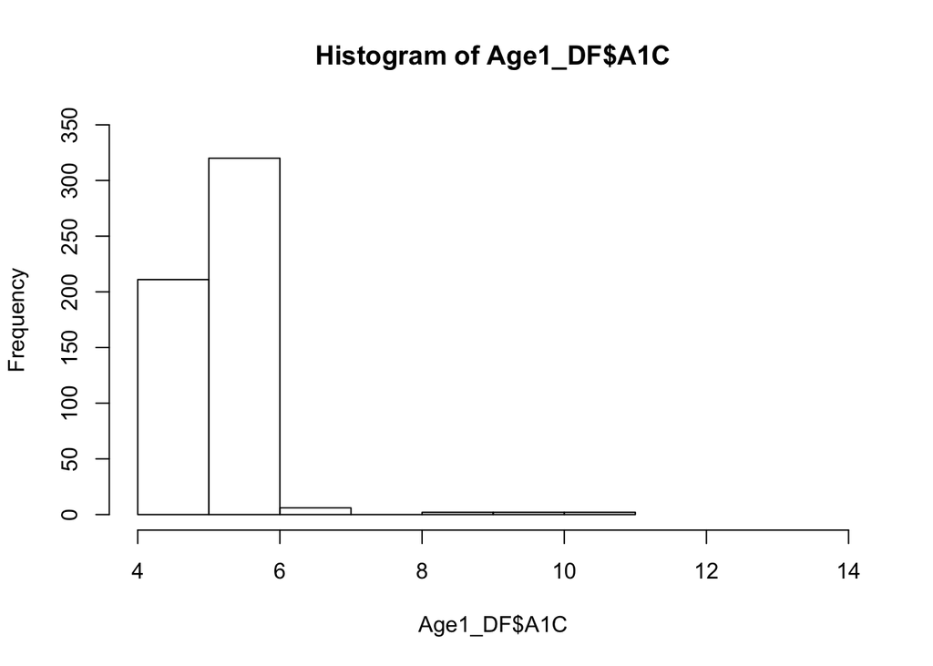

```r
HANES_Age1 <- HANES$AGEGROUP == "20-39"
HANES_Age2 <- HANES$AGEGROUP == "40-59"
HANES_Age3 <- HANES$AGEGROUP == "60+"
Age1_DF <- HANES[HANES_Age1,]
Age2_DF <- HANES[HANES_Age2,]
Age3_DF <- HANES[HANES_Age3,]
hist(Age1_DF$A1C,xlim = c(4,14),ylim = c(0,350), breaks = 7)
```

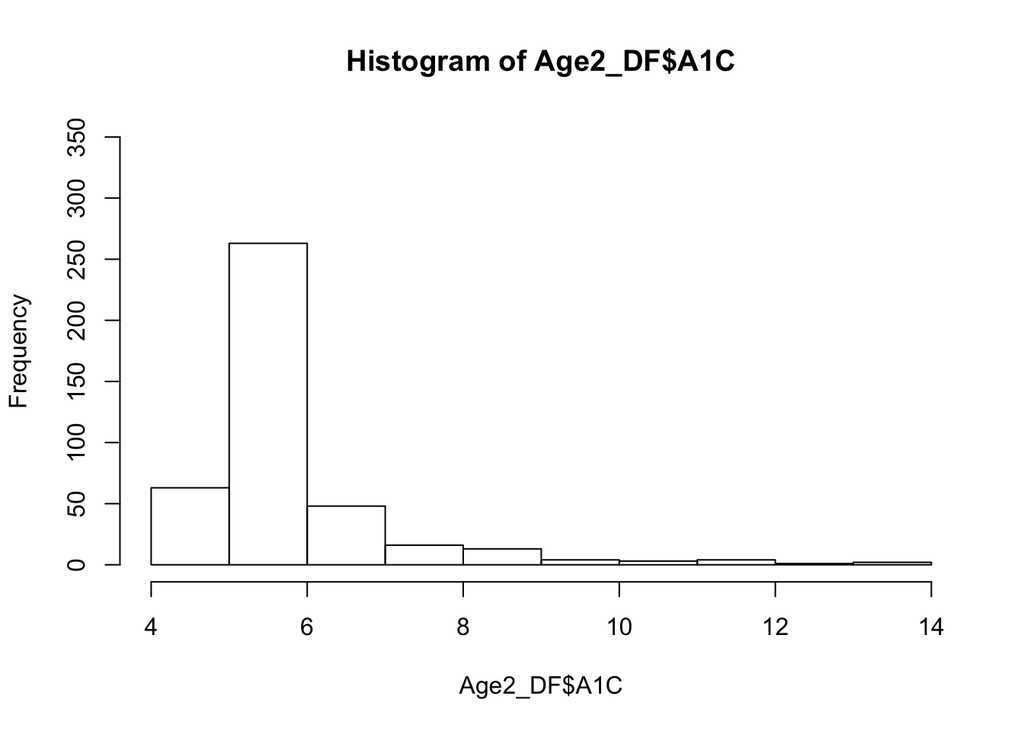

```r
hist(Age2_DF$A1C,xlim = c(4,14),ylim = c(0,350), breaks = 10)
```

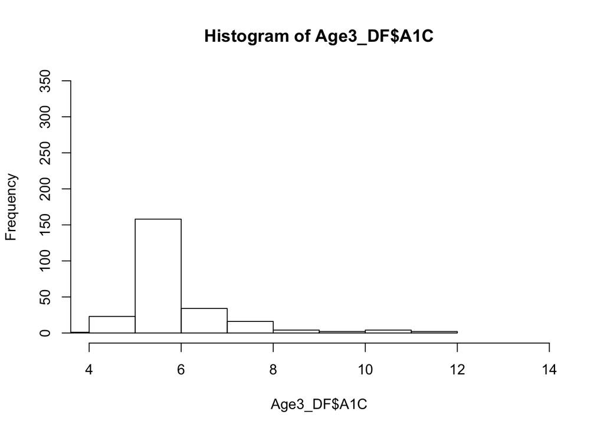

```r
hist(Age3_DF$A1C,xlim = c(4,14),ylim = c(0,350), breaks = 10)
```

The histogram is shifted further left in the first age group, but the distributions for 2 and 3 look similar. I don’t know of a less manual way to make the histograms comparable than setting the bins and axis lengths.

Try to find the distribution of one more numeric variable (other than A1C) for the three age-groups.

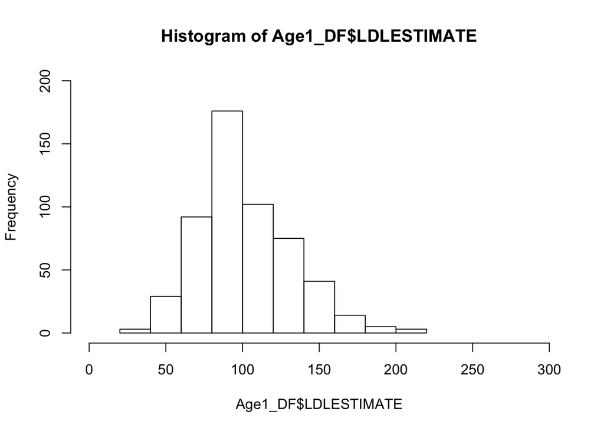

```r
hist(Age1_DF$LDLESTIMATE,xlim = c(0,300), ylim = c(0,200), breaks = 10)
```

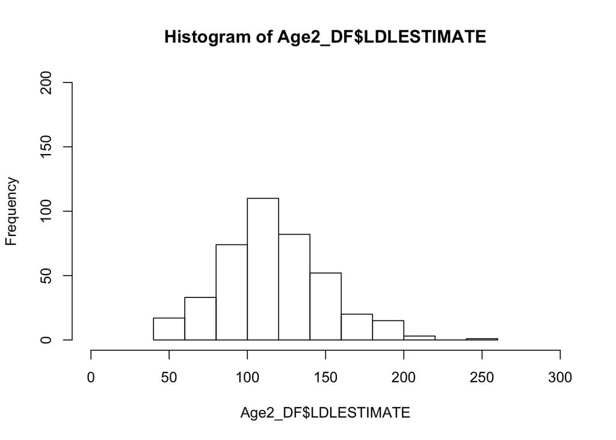

```r
hist(Age2_DF$LDLESTIMATE,xlim = c(0,300),ylim = c(0,200), breaks = 10)
```

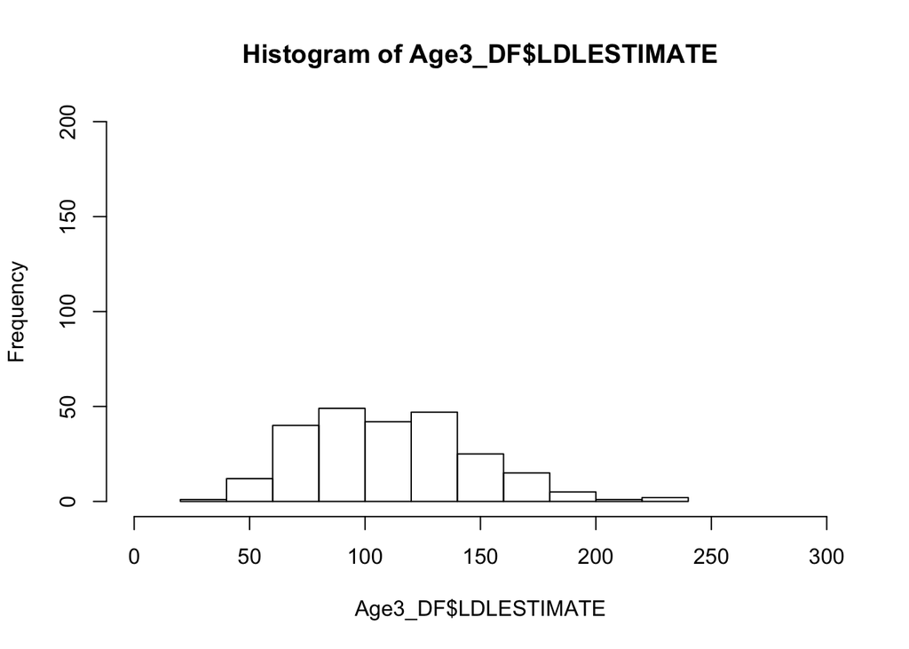

```r
hist(Age3_DF$LDLESTIMATE,xlim = c(0,300),ylim = c(0,200), breaks = 10)
```

I did this for LDL. As before, the distribution seems centered lower for the first age group.

Try some plots with a higher number of bins in the above exercise, what happens?

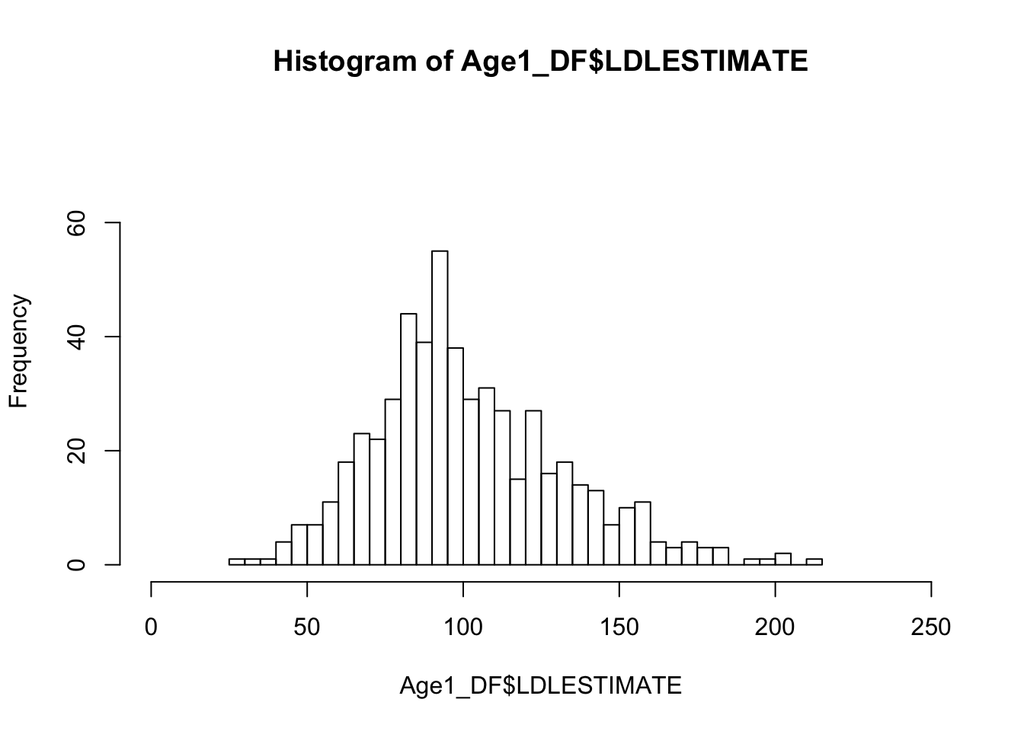

```r
hist(Age1_DF$LDLESTIMATE,xlim = c(0,250), ylim = c(0,75), breaks = 30)
```

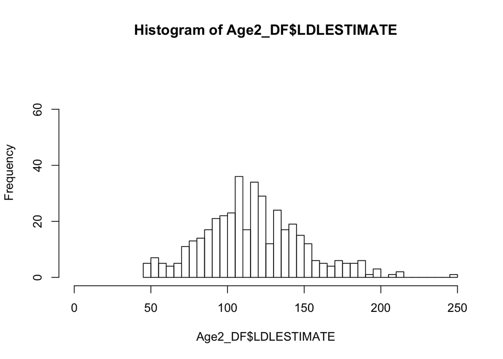

```r
hist(Age2_DF$LDLESTIMATE,xlim = c(0,250),ylim = c(0,75), breaks = 30)
```

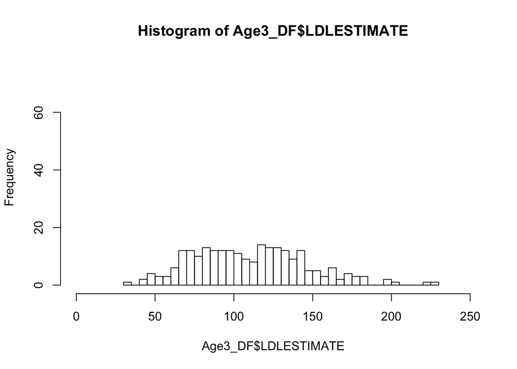

```r
hist(Age3_DF$LDLESTIMATE,xlim = c(0,250),ylim = c(0,75), breaks = 30)
```

The LDL estimate pattern still looks similar. I had to adjust the axis limits a bit so that there wasn’t too much white space. It’s now even more clear that the median is lower for the first age group. The second age group seems to peak around 110, whereas the third age group has a flatter distribution.

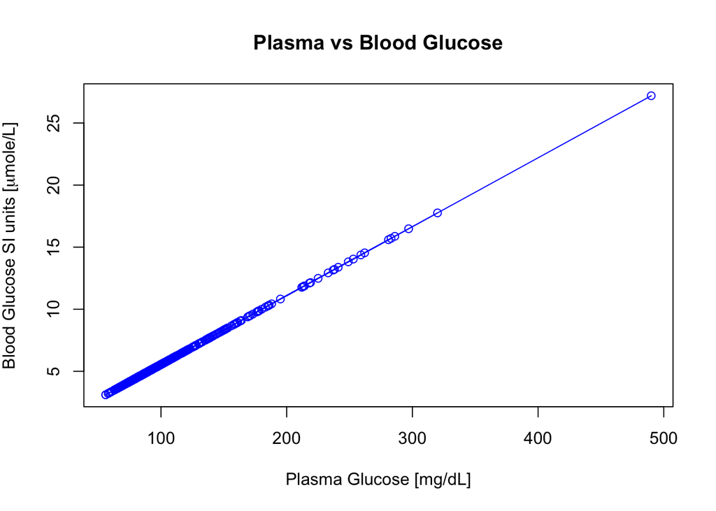

```r
#install.packages("Hmisc")
#library(Hmisc)
#label(HANES$GLUCOSE) <- "Plasma Glucose [mg/dL]"
plot(HANES$GLUCOSE, HANES$GLUCOSESI,
       xlab= "Plasma Glucose [mg/dL]", ylab = expression(paste("Blood Glucose SI units [", mu, "mole/L]")),
       main = "Plasma vs Blood Glucose", type = "o", col="blue")
```

Hmisc::label() stores label attributes for a variable. This isn’t working for me at the moment, because I can’t seem to load Hmisc, but I guess that it could make a label that would then show up as the relevant axis on al future graphs. It looks like you still have to specify: xlab = label(LDL)) in the code that you use to make the figure.

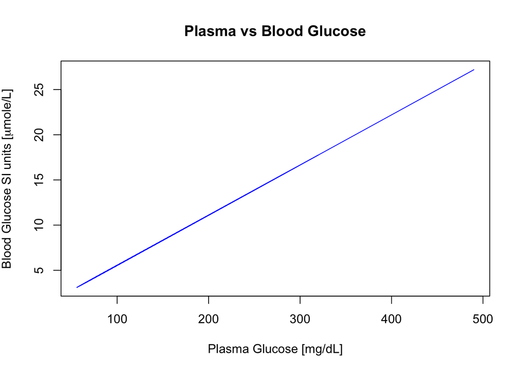

```r
plot(HANES$GLUCOSE, HANES$GLUCOSESI,
       xlab= "Plasma Glucose [mg/dL]", ylab = expression(paste("Blood Glucose SI units [", mu, "mole/L]")),
       main = "Plasma vs Blood Glucose", type = "l", col="blue")
```

This is a line plot.

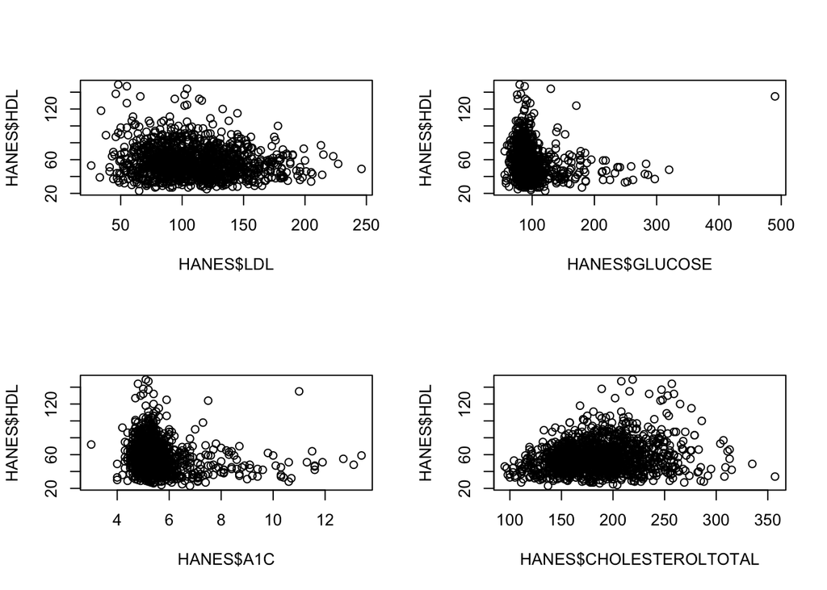

```r
  par(mfcol = c(2,2))
  plot(HANES$LDL, HANES$HDL)
  plot(HANES$A1C, HANES$HDL)
  plot(HANES$GLUCOSE, HANES$HDL)
  plot(HANES$CHOLESTEROLTOTAL, HANES$HDL)
```

```r
  par(mfrow = c(1,1))
```

mfcol fills the graphs in by column rather than by row.

Make a plot and add elements through the functions points(), lines(), segments() and text().

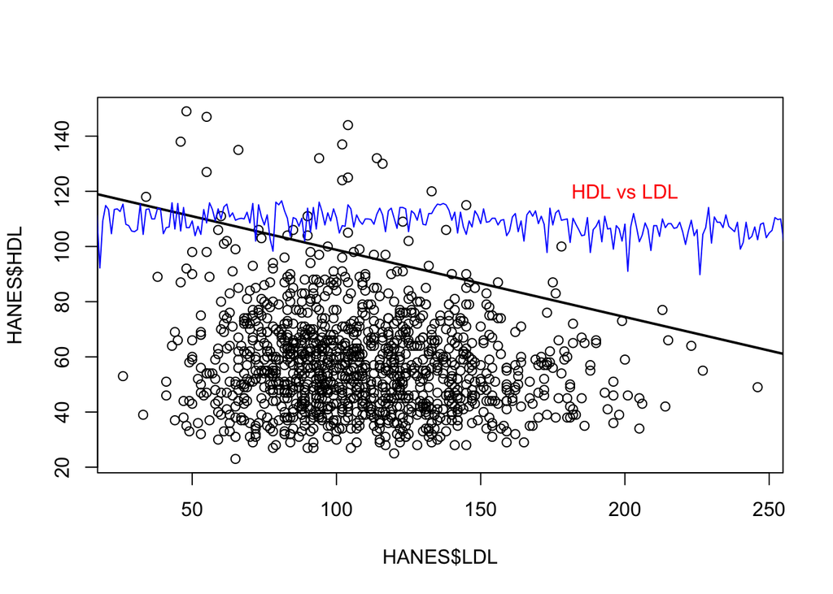

```r
plot(HANES$LDL, HANES$HDL)
ldl_hdl <- lm (HANES$LDL~HANES$HDL)
abline(coef(ldl_hdl),lwd = 2)
text(200,120, "HDL vs LDL",col = "red")
lines(fitted(ldl_hdl), col="blue") #not what I was expecting...
lines(y=40,x=40,col = "orange") #doesn't work
```